# 2-IPython slides

[figure not shown]

IPython provides a rich architecture for interactive computing with:

- Powerful interactive shells (terminal and Qt-based).
- A browser-based notebook with support for code, rich text, mathematical expressions, inline plots and other rich media.
- Support for interactive data visualization and use of GUI toolkits.
- Flexible, embeddable interpreters to load into your own projects.
- Easy to use, high performance tools for parallel computing.

### Installing IPython

```
$ pip install ipython --user
```

## IPython

### There are basically three flavors of IPython:

- the terminal-based interactive shell console
- the Qt-based interactive shell console
- the browser-based IPython notebooks aa

### IPython terminal

[figure not shown]

### IPython qtconsole

- It requires the Qt libraries and their respctive python bindings.
- It offers in-line plotting features as well as introspection and help as tooltips.

[figure not shown]

## IPython notebooks

The IPython Notebook is an interactive computational environment, in which you can combine code execution, rich text, mathematics, plots and rich media

### Some of the main features of the IPython Notebook app include:

- Display rich data representations (e.g. HTML / LaTeX / SVG) in the browser as a result of computations.
- Compose rich text using Markdown and HTML.
- Include mathematical equations, rendered directly in the browser by MathJax.
- Import standard Python scripts.
- In-browser editing, syntax highlighting, tab completion and autoindentation.
- Inline figures rendered by the matplotlib library with publication quality, in a range of formats (SVG / PDF / PNG).

[figure not shown]

#### First, let us install it

```
$ pip install ipython[all] --user
```

Now, let's run the ipython notebook server

```
$ ipython notebook
```

## Input/Output cache

```python
[i for i in range(5)]
```

```
[0, 1, 2, 3, 4]
```

```python
x = Out[1]
print x
```

```
[0, 1, 2, 3, 4]
```

```python
print _
print __
```

```
[0, 1, 2, 3, 4]
```

```python
print In[3]
```

```
x = Out[1]
print x
```

## Introspection and in-line docstrings

- Auto-complete
- In-line help
- Docstrings tooltips

### Auto-complete

- IPython provides TAB-completion and introspection for objects' attributes and methods.
- The TAB-completion also works for the filesystem, suggesting files and directories names.

```python
z = [1,2,3,4]
```

```
z. #press tab
z.append   z.count    z.extend   z.index    z.insert   z.pop      z.remove   z.reverse  z.sort
```

### Tooltips

You can press Shift+Tab when calling a method for a tooltip.

- press multiple times for more and mode information
- Press Shift+Tab 3 times to keep the tooltip while you type

```python
np.cumsum #press shift + tab
```

### Help

In case you need some help for an object or module, you can use the ?.

For example:

[figure not shown]

# Markdown

IPython notebook cells also support the Markdown syntax for rich text formating.

## Basic writing

### Headers

You can use one or more `#` before your heading text. The number of # you use will determine the size of the heading.

```
#Top level
##Second level
###Third level
```

This code on the top produces the result on the bottom.

# Top level

## Second level

### Third level

### Blockquotes

You can define blockquotes with a `>`

```
> This is a blockquote
```

produces

> This is a blockquote

### Styling text

```
*This text will be italic*
**This text will be bold**
```

*This text will be italic* **This text will be bold**

## Lists

### Unordered list

You can make an unordered list by preceding list items with either a `*` or a `-`.

```
* Item
* Item

- Item
- Item
```

- Item
- Item
- Item
- Item

### Ordered list

```
1. Item 1
  1. A corollary to the above item.
  2. Yet another point to consider.
2. Item 2
  * A corollary that does not need to be ordered.
    * This is indented four spaces, because it's two spaces further than the item above.
    * You might want to consider making a new list.
3. Item 3
```

produces

1. Item 1
   1. A corollary to the above item.
   2. Yet another point to consider.
2. Item 2
   - A corollary that does not need to be ordered.
     - This is indented four spaces, because it's two spaces further than the item above.
     - You might want to consider making a new list.
3. Item 3

### Source code

You can use triple backquotes `` ``` ``to delimit a block where you want to output a piece of code.

```
def fact(x):
    if x == 1:
        return 1
    else:
        return x*fact(x-1)
```

If you want to highlight the syntax for a particular language, you can do

```
def fact(x):
    if x == 1:
        return 1
    else:
        return x*fact(x-1)
```

The syntax highlight feature works for many different languages.

```
import java.util.*;

public class Sum2 {
   public static void main(String[] args) {
      Scanner in = new Scanner(System.in); // Standard input
      System.out.println(in.nextInt() + in.nextInt()); // Standard output
   }
}
```

```
// Standard input-output streams
#include <iostream>
using namespace std;
void main()
{
   int a, b;
   cin >> a >> b;
   cout << a + b << endl;
}
```

### $\LaTeX$

Markdown cells can also render$\LaTeX$ equations, either in line: $p(x)\propto x^{-\alpha}e^{-\beta x}$ or displayed

\begin{equation} \int \frac{d\theta}{1+\theta^2}= \tan^{-1}\theta+C \end{equation}

```
Latex
Markdown cells can also render $\LaTeX$ equations, either in line: $p(x)\propto x^{-\alpha}e^{-\beta x}$ or displayed
\begin{equation}
\int  \frac{d\theta}{1+\theta^2}=\tan^{-1}\theta+C
\end{equation}
```

### HTML

```
<table>
    <tr>
        <th>Header 1</th>
        <th>Header 2</th>
    </tr>
    <tr>
        <td>row 1, cell 1</td>
        <td>row 1, cell 2</td>
    </tr>
    <tr>
        <td>row 2, cell 1</td>
        <td>row 2, cell 2</td>
    </tr>
</table>
```

| Header 1 | Header 2 |
| --- | --- |
| row 1, cell 1 | row 1, cell 2 |
| row 2, cell 1 | row 2, cell 2 |

### Images

There are many different ways to insert images into IPython notebooks. Markdown cells support both the Markdown syntax

```
markdown
![img](./img/ipython.png)
```

and the HTML syntax.

```
HTML
<img src="./img/ipython.png" width="200">
```

[figure not shown]

The HTML is more flexible since it gives you more control on how the image is gonna be displayed.

### Videos

It's also possible to embed videos into Markdown cells.

```
HTML
<video controls src="./img/animation.m4v" />
```

[video not shown]

## IPython magics

IPython has a set of predefined ‘magic functions’ that you can call with a command line style syntax. There are two kinds of magics, line-oriented and cell-oriented.

- %timeit
- %store

*you read more about these and other magic functions here: https://ipython.org/ipython-doc/dev/interactive/tutorial.html#magic-functions

## %timeit

Simple way to test the running time of a piece of code

```python
def fib(n):
    if n<=2:
        result= 1
    else:
        result = fib(n-1)+fib(n-2)
    return result

def fib_prev(n):
    prev1 = 0
    prev2 = 1
    for i in range(n):
        prev1,prev2 = prev2,prev1+prev2
    return prev1

memo = {}
def memoized_fib(n):
    if memo.has_key(n):
        return memo[n]
    else:
        if n == 1 or n == 2:
            result = 1
        else:
            result = memoized_fib(n-1) + memoized_fib(n-2)
        memo[n] = result
        return result
```

```python
%timeit fib(30)
```

```
1 loops, best of 3: 270 ms per loop
```

```python
%timeit fib_prev(30)
```

```
100000 loops, best of 3: 4.49 µs per loop
```

```python
%timeit memoized_fib(30)
```

```
The slowest run took 10.86 times longer than the fastest. This could mean that an intermediate result is being cached
1000000 loops, best of 3: 263 ns per loop
```

```python
times_recursive = []
times_iter = []
times_dynamic = []
for i in range(10,30):
    t1 = %timeit -o -n 10 fib(i)
    t2 = %timeit -o -n 10 fib_prev(i)
    t3 = %timeit -o -n 10 memoized_fib(i)
    times_recursive.append(t1.best)
    times_iter.append(t2.best)
    times_dynamic.append(t3.best)
```

```
10 loops, best of 3: 36.2 µs per loop
10 loops, best of 3: 1.91 µs per loop
10 loops, best of 3: 691 ns per loop
10 loops, best of 3: 27.4 µs per loop
10 loops, best of 3: 1.48 µs per loop
10 loops, best of 3: 501 ns per loop
10 loops, best of 3: 71.2 µs per loop
10 loops, best of 3: 2.88 µs per loop
10 loops, best of 3: 691 ns per loop
10 loops, best of 3: 75.3 µs per loop
10 loops, best of 3: 1.6 µs per loop
10 loops, best of 3: 501 ns per loop
10 loops, best of 3: 166 µs per loop
10 loops, best of 3: 2.81 µs per loop
10 loops, best of 3: 310 ns per loop
```

[output cut: 45 more lines]

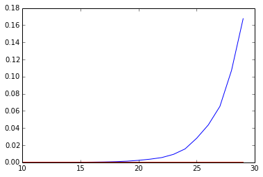

```python
import matplotlib.pyplot as plt
%matplotlib inline
plt.plot(range(10,30),times_recursive)
plt.plot(range(10,30),times_iter)
plt.plot(range(10,30),times_dynamic)
```

## %store

The %store magic provides a lightweight storage.

```python
%store times_recursive
%store times_iter
%store times_dynamic
```

```
Stored 'times_recursive' (list)
Stored 'times_iter' (list)
Stored 'times_dynamic' (list)
```

```python
%store
```

```
Stored variables and their in-db values:
times_dynamic               -> [6.914138793945312e-07, 5.006790161132813e-07, 6.9
times_iter                  -> [1.9073486328125e-06, 1.4781951904296875e-06, 2.88
times_recursive             -> [3.619194030761719e-05, 2.7394294738769533e-05, 7.
```

restarting the kernel

```python
%who
```

```
Interactive namespace is empty.
```

```python
%store -r
```

```python
%who
```

```
times_dynamic	 times_iter	 times_recursive
```

```python
times_dynamic
```

```
[6.914138793945312e-07,
 5.006790161132813e-07,
 6.914138793945312e-07,
 5.006790161132813e-07,
 3.0994415283203126e-07,
 3.0994415283203126e-07,
 2.86102294921875e-07,
 2.86102294921875e-07,
 3.0994415283203126e-07,
 2.86102294921875e-07,
 3.0994415283203126e-07,
 3.0994415283203126e-07,
 3.0994415283203126e-07,
 3.0994415283203126e-07,
 3.0994415283203126e-07,
 3.0994415283203126e-07,
 2.86102294921875e-07,
 3.0994415283203126e-07,
 5.006790161132813e-07,
 2.86102294921875e-07]
```